# AI Stocks and Market Bubble: Quick Report

Author

Atisha Karki & Venkat Satya Uday Dhanush Karri

Published

September 28, 2025

###### **Purpose**

We came across this article [“Are AI Stocks Driving A Stock Market Tech Bubble?”](https://www.investors.com/news/ai-stocks-stock-market-tech-bubble-valuations/) from Investor’s Business Daily. AI stocks (Nvidia, Meta, TSM, etc.) have seen large gains in 2025. Through this report we have examined whether the recent surge in AI-related stocks shows signs of a speculative **market bubble**. The analysis focuses on three complementary approaches: (1) Descriptive plotting , (2) Simple valuation checks and (3) Basic bubble diagnostics.

###### **1. Setup**

```python
import pandas as pd
import numpy as np
import matplotlib.pyplot as plt
from datetime import datetime
from statsmodels.tsa.stattools import adfuller

# plotting defaults
plt.rcParams.update({"figure.figsize": (10,5), "grid.linewidth": 0.5})

# user parameters (edit as needed)
TICKERS = ["NVDA", "MSFT", "GOOG", "META", "AMD"]
START = "2018-01-01"
END = "2025-08-31"
DATA_SOURCE = "yfinance"

# helper functions

def log_returns(series):
    return np.log(series).diff().dropna()
```

###### **2. Data**

This section downloads adjusted close prices and constructs returns for our analysis.

```python
import yfinance as yf

def download_prices(tickers, start, end):
    data = yf.download(tickers, start=start, end=end, progress=False, auto_adjust=False)
    # take adjusted close if available
    if ('Adj Close' in data.columns):
        prices = data['Adj Close']
    elif ('Adj Close' in data):
        prices = data['Adj Close']
    else:
        prices = data['Close']
    return prices

prices = download_prices(TICKERS, START, END)
prices.to_csv('prices_used.csv')

# quick preview
prices.tail()
```

| Ticker Date | AMD | GOOG | META | MSFT | NVDA |
| --- | --- | --- | --- | --- | --- |
| 2025-08-25 | 163.360001 | 208.973221 | 752.791870 | 504.260010 | 179.799866 |
| 2025-08-26 | 166.619995 | 207.764297 | 753.591370 | 502.040009 | 181.759750 |
| 2025-08-27 | 167.130005 | 208.024078 | 746.875916 | 506.739990 | 181.589767 |
| 2025-08-28 | 168.580002 | 212.180344 | 750.603394 | 509.640015 | 180.159836 |
| 2025-08-29 | 162.630005 | 213.339310 | 738.201782 | 506.690002 | 174.170166 |

###### **3. Basic metrics & plots**

###### **3.1 Cumulative returns (comparison vs S&P 500)**

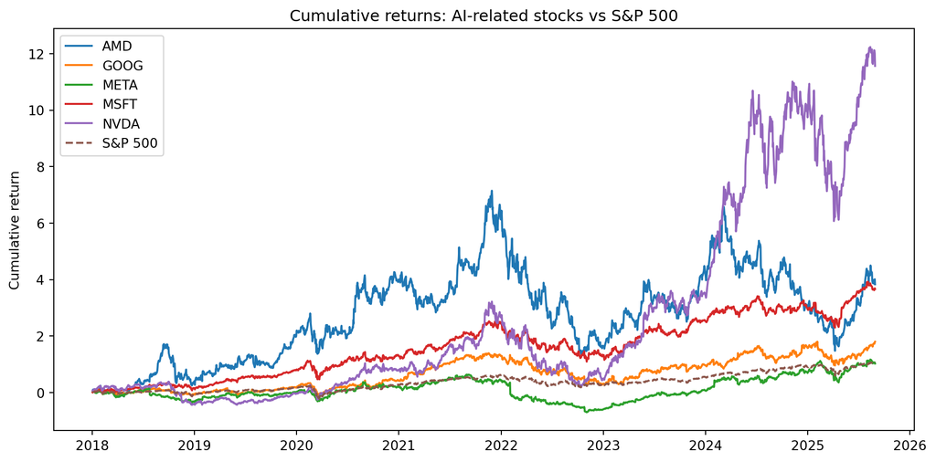

```python
sp500 = yf.download('^GSPC', start=START, end=END, progress=False)
sp_prices = sp500['Adj Close'] if 'Adj Close' in sp500.columns else sp500['Close']

returns = prices.apply(log_returns)
sp_returns = np.log(sp_prices).diff().dropna()

cum_returns = (returns + 1).cumprod() - 1
cum_sp = (sp_returns + 1).cumprod() - 1

# plot
for ticker in cum_returns.columns:
    plt.plot(cum_returns.index, cum_returns[ticker], label=ticker)
plt.plot(cum_sp.index, cum_sp, label='S&P 500', linestyle='--')
plt.title('Cumulative returns: AI-related stocks vs S&P 500')
plt.ylabel('Cumulative return')
plt.legend()
plt.tight_layout()
plt.savefig('cum_returns.png', dpi=300)
plt.show()
```

AI-related stocks, especially Nvidia, have driven returns far above the broader market. However, the divergence suggests a mix of fundamentals (MSFT) and momentum-driven gains (NVDA, AMD), highlighting both opportunities and bubble risks.

###### **3.2 Rolling volatility**

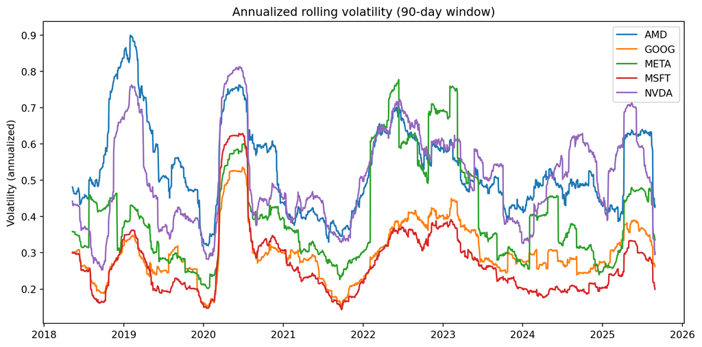

```python
rolling_win = 90  # ~ 3 months of daily data
rolling_vol = returns.rolling(window=rolling_win).std() * np.sqrt(252)

for ticker in rolling_vol.columns:
    plt.plot(rolling_vol.index, rolling_vol[ticker], label=ticker)
plt.title(f'Annualized rolling volatility ({rolling_win}-day window)')
plt.ylabel('Volatility (annualized)')
plt.legend()
plt.tight_layout()
plt.savefig('rolling_vol.png', dpi=300)
plt.show()
```

The chart highlights clear differences in the risk profiles of AI-related stocks. Nvidia (NVDA) and AMD show the highest and most frequent volatility spikes, especially during periods of rapid price appreciation, which suggests that much of their performance has been fueled by speculative trading and sensitivity to AI news cycles. Meta (META) displays moderate volatility overall, but with sharp surges around 2022–2023 when the company shifted focus toward AI and restructuring, reflecting investor uncertainty. In contrast, Google (GOOG) and Microsoft (MSFT) maintain consistently lower volatility, underscoring their position as more stable mega-cap firms where AI contributes to growth on top of established fundamentals.

###### **4. Valuation checks**

A time series of P/E or P/S ratios is ideal for valuation analysis, as it captures changes over time. In this case, we used only a **snapshot of trailing P/E** using `yfinance`, providing a **cross-sectional view of relative valuations** at a single point in time rather than a full time-series perspective.

```python
pe_snapshot = {}
for t in TICKERS:
    try:
        info = yf.Ticker(t).info
        pe_snapshot[t] = info.get('trailingPE', np.nan)
    except Exception as e:
        pe_snapshot[t] = np.nan

pd.Series(pe_snapshot).to_frame('trailingPE')
```

|  | trailingPE |
| --- | --- |
| NVDA | 50.766384 |
| MSFT | 37.442165 |
| GOOG | 26.379936 |
| META | 26.957232 |
| AMD | 95.485040 |

Based on the snapshot P/E data, AMD appears extremely expensive with a P/E of 95.5, reflecting very high market expectations likely driven by momentum rather than current earnings. NVDA is also relatively expensive at 50.8, suggesting strong growth expectations, particularly from AI-related developments. MSFT, with a P/E of 37.4, sits in the middle, indicating a balance between fundamentals and growth optimism. GOOG and META have the lowest P/Es, around 26–27, suggesting that their valuations are more grounded in fundamentals rather than speculative growth.

###### **5. Bubble diagnostics**

```python
# Price acceleration (z-score of pct change)
window_accel = 30  # 30-day change
pct_change = prices.pct_change(window_accel)
pct_z = (pct_change - pct_change.mean()) / pct_change.std()

# Threshold for extreme acceleration
threshold = 3
extreme_flags = (pct_z.abs() > threshold)

# Rolling ADF test (log-prices)
window_adf = 120  # rolling window of 120 trading days (~6 months)
rolling_adf_stats = pd.DataFrame(index=prices.index, columns=prices.columns)

for col in prices.columns:
    log_price = np.log(prices[col].dropna())
    for i in range(window_adf, len(log_price)):
        try:
            adf_stat = adfuller(log_price[i-window_adf:i])[0]
            rolling_adf_stats.loc[log_price.index[i], col] = adf_stat
        except:
            rolling_adf_stats.loc[log_price.index[i], col] = np.nan
```

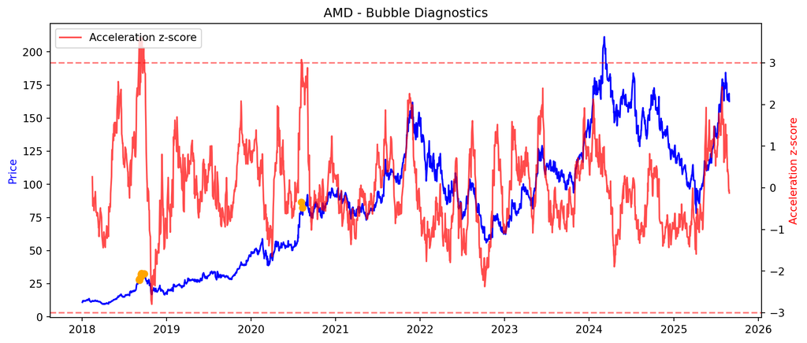

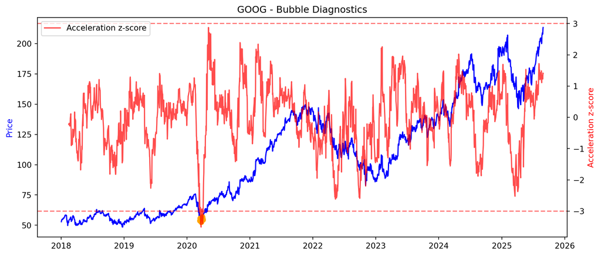

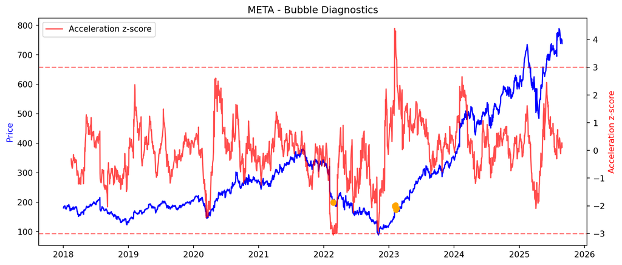

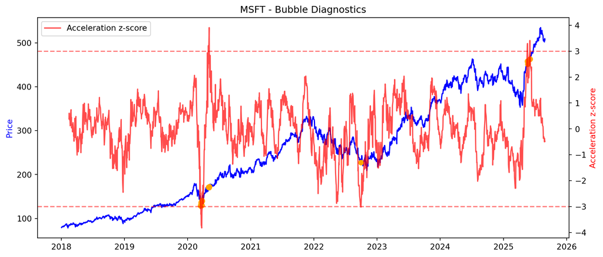

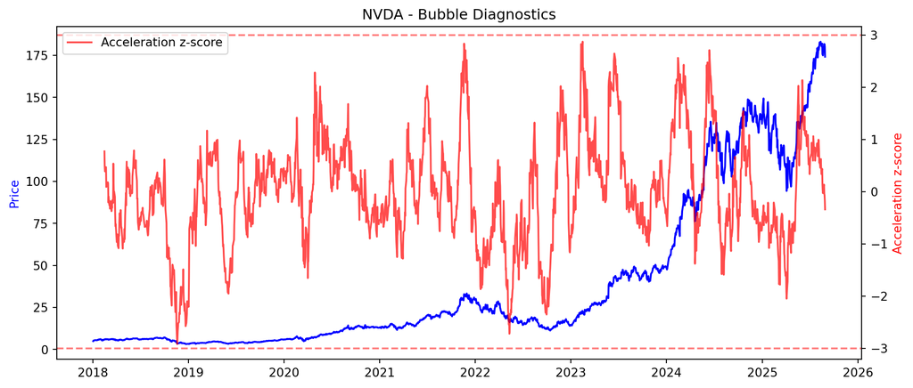

```python
# Plot results
for col in prices.columns:
    fig, ax1 = plt.subplots(figsize=(12, 5))

    ax1.set_title(f"{col} - Bubble Diagnostics")
    ax1.plot(prices[col], label='Price', color='blue')
    ax1.set_ylabel('Price', color='blue')

    ax2 = ax1.twinx()
    ax2.plot(pct_z[col], label='Acceleration z-score', color='red', alpha=0.7)
    ax2.axhline(threshold, color='red', linestyle='--', alpha=0.5)
    ax2.axhline(-threshold, color='red', linestyle='--', alpha=0.5)
    ax2.set_ylabel('Acceleration z-score', color='red')

    # Highlight extreme acceleration
    ax1.scatter(prices.index[extreme_flags[col]], prices[col][extreme_flags[col]],
                color='orange', label='Extreme Acceleration', zorder=5)

    plt.legend(loc='upper left')
    plt.show()
```

| Ticker | Latest Rolling ADF Stat | Acceleration Flags (30d) |
| --- | --- | --- |
| AMD | -0.690047 | 13 |
| GOOG | 0.488782 | 12 |
| META | -1.02853 | 11 |
| MSFT | -1.082752 | 16 |
| NVDA | -0.405284 | 0 |

The bubble diagnostics for AMD, GOOG, META, MSFT, and NVDA combine two practical checks: short-term price acceleration and rolling ADF tests on log-prices. The 30-day price acceleration z-scores highlight how often each stock experienced unusually large price movements. MSFT, AMD, GOOG, and META all show frequent extreme acceleration, with 16, 13, 12, and 11 instances respectively, suggesting strong short-term momentum and possible speculative trading. NVDA, in contrast, had no acceleration flags, indicating smoother price trends over the same period.

The rolling ADF statistics provide insight into the stationarity of log-prices. More negative ADF values indicate mean-reverting (stationary) prices, whereas values near zero or positive indicate non-stationary, trending prices that may be prone to explosive behavior. MSFT (-1.08) and META (-1.03) are slightly more negative but still far from strongly stationary, indicating moderate trend persistence. AMD (-0.69), NVDA (-0.41), and GOOG (0.49) show weaker or positive ADF values, consistent with non-stationary, trending prices.

When combining both diagnostics, MSFT, AMD, GOOG, and META exhibit characteristics consistent with momentum-driven price trends: frequent large price jumps alongside non-stationary behavior. This pattern can signal potential speculative pressure, though it is not definitive proof of a bubble. NVDA, despite its non-stationary price trend, shows no extreme short-term acceleration, suggesting its price increases have been smoother and less speculative. Overall, these checks provide a practical, high-level view of which stocks may be experiencing rapid, momentum-driven price movements, but more rigorous econometric tests would be required to conclusively identify bubbles.

However, these diagnostics are simplified checks. True bubble detection requires more advanced tests (GSADF, PE-ADF) and careful consideration of fundamentals and market conditions.